# Cechy charakterystyczne Irysów

#### Materiał opracowany przez Marcina Salskiego w ramach zadania domowego Modułu 10

#### Wersja skrócona - artykuł

## Ogólny przegląd danych

Zbiór danych zawiera informacje o trzech gatunkach irysów: Iris setosa, Iris versicolor, i Iris virginica.

Dane obejmują pomiary czterech cech: długość i szerokość działki kielicha oraz długość i szerokość płatka.

Każdy wiersz w zbiorze danych reprezentuje pojedynczy kwiat, a wartości pomiarów są podane w centymetrach.

Zbiór składa się z 150 próbek, po 50 dla każdego gatunku, i jest szeroko stosowany jako podstawowy zbiór danych do testowania algorytmów klasyfikacji oraz w nauce o danych i uczeniu maszynowym.

Kolumny:

- **długość kielicha (sepal length)** - Długość kielicha w cm
- **szerokość kielicha (sepal width)** - Szerokość kielicha w cm
- **długość płatka (petal length)** - Długość płatka w cm
- **szerokość płatka (petal width)** - Szerokość płatka w cm
- **klasa (class)** - Klasa irysa (setosa, versicolor, virginica)

Oto jak wygląda próbka losowo wybranych dziesięciu wierszy z bazy danych.

|  | długość kielicha (sepal length) | szerokość kielicha (sepal width) | długość płatka (petal length) | szerokość płatka (petal width) | klasa (class) |
| --- | --- | --- | --- | --- | --- |
| 74 | 6.4 | 2.9 | 4.3 | 1.3 | Iris-versicolor |
| 80 | 5.5 | 2.4 | 3.8 | 1.1 | Iris-versicolor |
| 65 | 6.7 | 3.1 | 4.4 | 1.4 | Iris-versicolor |
| 106 | 4.9 | 2.5 | 4.5 | 1.7 | Iris-virginica |
| 126 | 6.2 | 2.8 | 4.8 | 1.8 | Iris-virginica |
| 28 | 5.2 | 3.4 | 1.4 | 0.2 | Iris-setosa |
| 39 | 5.1 | 3.4 | 1.5 | 0.2 | Iris-setosa |
| 100 | 6.3 | 3.3 | 6.0 | 2.5 | Iris-virginica |
| 147 | 6.5 | 3.0 | 5.2 | 2.0 | Iris-virginica |
| 98 | 5.1 | 2.5 | 3.0 | 1.1 | Iris-versicolor |

I jeszcze trochę informacji ogólnych o bazie i jakości danych zawartych w poszczególnych kolumnach

```
<class 'pandas.core.frame.DataFrame'>
RangeIndex: 150 entries, 0 to 149
Data columns (total 5 columns):
 #   Column                            Non-Null Count  Dtype
---  ------                            --------------  -----
 0   długość kielicha (sepal length)   150 non-null    float64
 1   szerokość kielicha (sepal width)  150 non-null    float64
 2   długość płatka (petal length)     150 non-null    float64
 3   szerokość płatka (petal width)    150 non-null    float64
 4   klasa (class)                     150 non-null    object
dtypes: float64(4), object(1)
memory usage: 6.0+ KB
```

|  | długość kielicha (sepal length) | szerokość kielicha (sepal width) | długość płatka (petal length) | szerokość płatka (petal width) |
| --- | --- | --- | --- | --- |
| count | 150.000000 | 150.000000 | 150.000000 | 150.000000 |
| mean | 5.843333 | 3.054000 | 3.758667 | 1.198667 |
| std | 0.828066 | 0.433594 | 1.764420 | 0.763161 |
| min | 4.300000 | 2.000000 | 1.000000 | 0.100000 |
| 25% | 5.100000 | 2.800000 | 1.600000 | 0.300000 |
| 50% | 5.800000 | 3.000000 | 4.350000 | 1.300000 |
| 75% | 6.400000 | 3.300000 | 5.100000 | 1.800000 |
| max | 7.900000 | 4.400000 | 6.900000 | 2.500000 |

Dostępna baza danych jest niewielka ale dobra. Mamy w niej 150 rekordów. Nie ma brakujących wartości ani też wartości, które wyglądałyby na błędne lub odstające niestandardowo od reszty. Dane zawarte w każdej kolumnie mąją jednolity format i sensowne wartości.

## Analiza poszczególnych odmian Irysa

Dostępne dane zawierają charakterystyki trzech odmian Irysów. Na każdą odmianę przypada po 50 rekordów.

```
Iris-setosa        50
Iris-versicolor    50
Iris-virginica     50
Name: klasa (class), dtype: int64
```

### Charakterystyka odmiany Versicolor

|  | Dł. kielicha | Szer. kielicha | Dł. płatka | Szer. płatka |
| --- | --- | --- | --- | --- |
| count | 50.000000 | 50.000000 | 50.000000 | 50.000000 |
| mean | 5.936000 | 2.770000 | 4.260000 | 1.326000 |
| std | 0.516171 | 0.313798 | 0.469911 | 0.197753 |
| min | 4.900000 | 2.000000 | 3.000000 | 1.000000 |
| 25% | 5.600000 | 2.525000 | 4.000000 | 1.200000 |
| 50% | 5.900000 | 2.800000 | 4.350000 | 1.300000 |
| 75% | 6.300000 | 3.000000 | 4.600000 | 1.500000 |
| max | 7.000000 | 3.400000 | 5.100000 | 1.800000 |

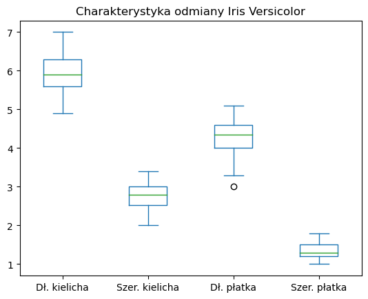

Odmiana Iris-Versicolor ma kielichy o długości od 4,9 do 7,0 cm (średnio 5,9 cm) i szerokości od 2,0 do 3,4 cm (średnio 2,8 cm). Płatki tej odmiany mają długość od 3,0 do 5,1 cm (średnia 4,3 cm) i szerokość od 1,0 do 1,8 cm (średnio 1,3 cm)

Widoczna jest korelacja między długością a długością kielicha ora między szerokością płatka i szerokością kielicha. To logiczne - kielich powstaje z ułożonych w okręgu płatków. Im większe płatki tym większy kielich.

Poniżej znajduje się macież korelacji dla wymiarów odmiany Versicolor.

|  | Dł. kielicha | Szer. kielicha | Dł. płatka | Szer. płatka |
| --- | --- | --- | --- | --- |
| Dł. kielicha | 1.000000 | 0.525911 | 0.754049 | 0.546461 |
| Szer. kielicha | 0.525911 | 1.000000 | 0.560522 | 0.663999 |
| Dł. płatka | 0.754049 | 0.560522 | 1.000000 | 0.786668 |
| Szer. płatka | 0.546461 | 0.663999 | 0.786668 | 1.000000 |

### Charakterystyka odmiany Virginica

|  | Dł. kielicha | Szer. kielicha | Dł. płatka | Szer. płatka |
| --- | --- | --- | --- | --- |
| count | 50.00000 | 50.000000 | 50.000000 | 50.00000 |
| mean | 6.58800 | 2.974000 | 5.552000 | 2.02600 |
| std | 0.63588 | 0.322497 | 0.551895 | 0.27465 |
| min | 4.90000 | 2.200000 | 4.500000 | 1.40000 |
| 25% | 6.22500 | 2.800000 | 5.100000 | 1.80000 |
| 50% | 6.50000 | 3.000000 | 5.550000 | 2.00000 |
| 75% | 6.90000 | 3.175000 | 5.875000 | 2.30000 |
| max | 7.90000 | 3.800000 | 6.900000 | 2.50000 |

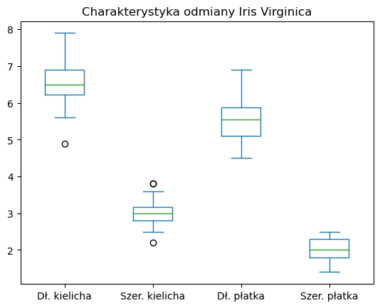

Odmiana Iris-Virginica ma kielichy o długości od 4,9 do 7,9 cm (średnio 6,6 cm) i szerokości od 2,2 do 3,8 cm (średnio 3 cm). Płatki tej odmiany mają długość od 4,5 do 6,9 cm (średnia 5,6 cm) i szerokość od 1,4 do 2,5 cm (średnio 2cm).

Poniżej znajduje się macierz korelacji dla wymiarów odmiany Virginica.

|  | Dł. kielicha | Szer. kielicha | Dł. płatka | Szer. płatka |
| --- | --- | --- | --- | --- |
| Dł. kielicha | 1.000000 | 0.457228 | 0.864225 | 0.281108 |
| Szer. kielicha | 0.457228 | 1.000000 | 0.401045 | 0.537728 |
| Dł. płatka | 0.864225 | 0.401045 | 1.000000 | 0.322108 |
| Szer. płatka | 0.281108 | 0.537728 | 0.322108 | 1.000000 |

### Charakterystyka odmiany Setosa

|  | Dł. kielicha | Szer. kielicha | Dł. płatka | Szer. płatka |
| --- | --- | --- | --- | --- |
| count | 50.00000 | 50.000000 | 50.000000 | 50.00000 |
| mean | 5.00600 | 3.418000 | 1.464000 | 0.24400 |
| std | 0.35249 | 0.381024 | 0.173511 | 0.10721 |
| min | 4.30000 | 2.300000 | 1.000000 | 0.10000 |
| 25% | 4.80000 | 3.125000 | 1.400000 | 0.20000 |
| 50% | 5.00000 | 3.400000 | 1.500000 | 0.20000 |
| 75% | 5.20000 | 3.675000 | 1.575000 | 0.30000 |
| max | 5.80000 | 4.400000 | 1.900000 | 0.60000 |

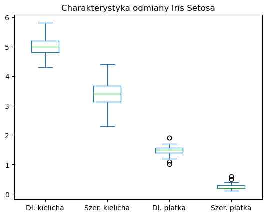

Odmiana Iris-Setosa ma kielichy o długości od 4,3 do 5,8 cm (średnio 5 cm) i szerokości od 2,3 do 4,4 cm (średnio 3,4 cm). Płatki tej odmiany mają długość od 1,0 do 1,9 cm (średnia 1,5 cm) i szerokość od 0,1 do 0,6 cm (średnio 0,24cm)

Brak jest korelacji pomiędzy wymiarami płatków i wymiarami kielichów. Wyraźnie mamy tu do czynienia z kielichem, który powstaje z wielu nakładających się na siebie małych płatków.

Poniżej znajduje się macierz korelacji dla wymiarów odmiany Setosa.

|  | Dł. kielicha | Szer. kielicha | Dł. płatka | Szer. płatka |
| --- | --- | --- | --- | --- |
| Dł. kielicha | 1.000000 | 0.746780 | 0.263874 | 0.279092 |
| Szer. kielicha | 0.746780 | 1.000000 | 0.176695 | 0.279973 |
| Dł. płatka | 0.263874 | 0.176695 | 1.000000 | 0.306308 |
| Szer. płatka | 0.279092 | 0.279973 | 0.306308 | 1.000000 |

## Podsumowanie i wnioski

Przeanalizowaliśmy rozmiary kielichów i płatków trzech odmian irysa. Mieliśmy bardzo dobre dane, które nie wymagały praktycznie żadnych poprawek. Jedyne korekty jakie wprowadziłem miały na celu poprawę widoczności danych na wykresach.

Dwie analizowane odmiany Versicolor i Virginica mają podobną budowę kielicha. Widać korelację pomiedzy wymiarami płatków i wymiarami kielicha co wydaje się bardzo naturalne. Płatki wyrastają z jednego miejsca i tworzą kielich więc wielkość kielicha wynika wprost z wymiarów pojedynczego płatka.

W przypadku odmiany setosa jest nieco inaczej. Płatki są malutkie a kielichy znacznie większe. Nie widać korelacji między wymiarami płatków a wymiarami kielicha. Widać natomiast korelację między wysokością i szerokością samego kielicha. Wyobrażam sobie jakąś dużą podłużną szypułkę obrastaną przez małe płatki. Ciekawą byłaby informacja o ilości płatków na jednym kielichu.